# Fórmulas de estimación Demanda de Nafta 2020

Irma Noemi No

7/7/2022

# 1 Estimación de Demanda de Nafta - Argentina 2020

## 1.1 Importamos los datos

Las datos a trabajar pertenecen a `bases` abiertas y oficiales obtenidas a través de las páginas: [datos.gob.ar](https://datos.gob.ar/), [producción de combustibles](http://datos.minem.gob.ar/dataset/produccion-de-combustibles) e [hidrocarburos de Argentina](https://www.argentina.gob.ar/economia/energia/hidrocarburos/refinacion-y-comercializacion-de-petroleo-gas-y-derivados-tablas-dinamicas) .

## 1.2 Armado de bases de datos para la estimación.

La venta de naftas y en general de combustibles, varía de acuerdo al día de la semana, ese dato sirve para la elaboración de una fórmula que estime la demanda de nafta. De acuerdo a los datos disponibles se realizarán estimaciones mensuales.

### 1.2.1 Ventas de combustible por mes.

Ventas de nafta mensuales por año

| AÑO | MES | DIA | VENTA | fecha |
| --- | --- | --- | --- | --- |
| 2013 | 1 | 3 | 289524.9 | 2013-01-01 |
| 2013 | 2 | 6 | 264616.9 | 2013-02-01 |
| 2013 | 3 | 6 | 274050.5 | 2013-03-01 |
| 2013 | 4 | 2 | 293841.1 | 2013-04-01 |
| 2013 | 5 | 4 | 283551.2 | 2013-05-01 |
| 2013 | 6 | 7 | 254371.7 | 2013-06-01 |
| 2013 | 7 | 2 | 298556.6 | 2013-07-01 |
| 2013 | 8 | 5 | 285746.0 | 2013-08-01 |
| 2013 | 9 | 1 | 270586.9 | 2013-09-01 |
| 2013 | 10 | 3 | 293925.6 | 2013-10-01 |
| 2013 | 11 | 6 | 286264.5 | 2013-11-01 |
| 2013 | 12 | 1 | 324716.9 | 2013-12-01 |
| 2014 | 1 | 4 | 318226.6 | 2014-01-01 |
| 2014 | 2 | 7 | 267557.4 | 2014-02-01 |
| 2014 | 3 | 7 | 271115.0 | 2014-03-01 |
| 2014 | 4 | 3 | 263514.4 | 2014-04-01 |
| 2014 | 5 | 5 | 246114.1 | 2014-05-01 |
| 2014 | 6 | 1 | 233928.0 | 2014-06-01 |
| 2014 | 7 | 3 | 253410.5 | 2014-07-01 |
| 2014 | 8 | 6 | 253784.2 | 2014-08-01 |
| 2014 | 9 | 2 | 254830.1 | 2014-09-01 |
| 2014 | 10 | 4 | 268783.0 | 2014-10-01 |
| 2014 | 11 | 7 | 254513.6 | 2014-11-01 |
| 2014 | 12 | 2 | 285068.4 | 2014-12-01 |
| 2015 | 1 | 5 | 296757.1 | 2015-01-01 |
| 2015 | 2 | 1 | 263762.7 | 2015-02-01 |
| 2015 | 3 | 1 | 271109.8 | 2015-03-01 |
| 2015 | 4 | 4 | 271762.1 | 2015-04-01 |
| 2015 | 5 | 6 | 253579.9 | 2015-05-01 |
| 2015 | 6 | 2 | 256944.8 | 2015-06-01 |

[output cut: 74 more lines]

### 1.2.2 Movilidad Google por mes 2020 y 2021.

Movilidad Promedio del mes

| AÑO | MES | MOVILIDAD | fecha |
| --- | --- | --- | --- |
| 2020 | 2 | -0.49 | 2020-02-15 |
| 2020 | 3 | -24.31 | 2020-03-01 |
| 2020 | 4 | -49.96 | 2020-04-01 |
| 2020 | 5 | -43.81 | 2020-05-01 |
| 2020 | 6 | -37.82 | 2020-06-01 |
| 2020 | 7 | -36.94 | 2020-07-01 |
| 2020 | 8 | -33.79 | 2020-08-01 |
| 2020 | 9 | -33.43 | 2020-09-01 |
| 2020 | 10 | -29.85 | 2020-10-01 |
| 2020 | 11 | -26.37 | 2020-11-01 |
| 2020 | 12 | -20.69 | 2020-12-01 |
| 2021 | 1 | -26.33 | 2021-01-01 |
| 2021 | 2 | -21.24 | 2021-02-01 |
| 2021 | 3 | -17.28 | 2021-03-01 |
| 2021 | 4 | -19.61 | 2021-04-01 |
| 2021 | 5 | -22.97 | 2021-05-01 |
| 2021 | 6 | -17.61 | 2021-06-01 |
| 2021 | 7 | -9.20 | 2021-07-01 |
| 2021 | 8 | -4.24 | 2021-08-01 |
| 2021 | 9 | -1.18 | 2021-09-01 |
| 2021 | 10 | 3.36 | 2021-10-01 |
| 2021 | 11 | 5.64 | 2021-11-01 |

## 1.3 Estimaciones de demanda en base a movilidad.

Se realizarán estimaciones mensuales.

Elaboramos un pronóstico con la demanda inicial del día correspondiente de cada mes.

El aspecto de la base de datos simplificada es:

Aspecto de base para modelizar la estimación

| AÑO | MES | DIA | VENTA | fecha | MOVILIDAD | MOVILIDADdif | VENTAant |
| --- | --- | --- | --- | --- | --- | --- | --- |
| 2020 | 1 | 4 | 327529.2 | 2020-01-01 | 0.00 | 0.00 | 327529.2 |
| 2020 | 2 | 7 | 308131.3 | 2020-02-01 | -0.49 | -0.49 | 327529.2 |
| 2020 | 3 | 1 | 236001.6 | 2020-03-01 | -24.31 | -23.82 | 308131.3 |
| 2020 | 4 | 4 | 102108.5 | 2020-04-01 | -49.96 | -25.65 | 236001.6 |
| 2020 | 5 | 6 | 156361.7 | 2020-05-01 | -43.81 | 6.15 | 102108.5 |
| 2020 | 6 | 2 | 196567.2 | 2020-06-01 | -37.82 | 5.99 | 156361.7 |
| 2020 | 7 | 4 | 222461.0 | 2020-07-01 | -36.94 | 0.88 | 196567.2 |
| 2020 | 8 | 7 | 233631.3 | 2020-08-01 | -33.79 | 3.15 | 222461.0 |
| 2020 | 9 | 3 | 235666.4 | 2020-09-01 | -33.43 | 0.36 | 233631.3 |
| 2020 | 10 | 5 | 247434.9 | 2020-10-01 | -29.85 | 3.58 | 235666.4 |
| 2020 | 11 | 1 | 268824.5 | 2020-11-01 | -26.37 | 3.48 | 247434.9 |
| 2020 | 12 | 3 | 332086.5 | 2020-12-01 | -20.69 | 5.68 | 268824.5 |
| 2021 | 1 | 6 | 326327.1 | 2021-01-01 | -26.33 | -5.64 | 332086.5 |
| 2021 | 2 | 2 | 297235.6 | 2021-02-01 | -21.24 | 5.09 | 326327.1 |
| 2021 | 3 | 2 | 330872.9 | 2021-03-01 | -17.28 | 3.96 | 297235.6 |
| 2021 | 4 | 5 | 283338.5 | 2021-04-01 | -19.61 | -2.33 | 330872.9 |
| 2021 | 5 | 7 | 247142.5 | 2021-05-01 | -22.97 | -3.36 | 283338.5 |
| 2021 | 6 | 3 | 258117.4 | 2021-06-01 | -17.61 | 5.36 | 247142.5 |
| 2021 | 7 | 5 | 313391.1 | 2021-07-01 | -9.20 | 8.41 | 258117.4 |
| 2021 | 8 | 1 | 316716.6 | 2021-08-01 | -4.24 | 4.96 | 313391.1 |

### 1.3.1 Correlación entre variables

Correlaciones entre variables

|  | AÑO | MES | DIA | VENTA | MOVILIDAD | MOVILIDADdif | VENTAant |
| --- | --- | --- | --- | --- | --- | --- | --- |
| AÑO | 1.000 | -0.307 | -0.010 | 0.469 | 0.399 | 0.208 | 0.483 |
| MES | -0.307 | 1.000 | -0.201 | -0.084 | -0.226 | 0.376 | -0.425 |
| DIA | -0.010 | -0.201 | 1.000 | -0.099 | -0.055 | 0.036 | -0.082 |
| VENTA | 0.469 | -0.084 | -0.099 | 1.000 | 0.841 | 0.435 | 0.713 |
| MOVILIDAD | 0.399 | -0.226 | -0.055 | 0.841 | 1.000 | 0.296 | 0.716 |
| MOVILIDADdif | 0.208 | 0.376 | 0.036 | 0.435 | 0.296 | 1.000 | -0.221 |
| VENTAant | 0.483 | -0.425 | -0.082 | 0.713 | 0.716 | -0.221 | 1.000 |

Del cuadro anterior se distinguen las variables MOVILIDAD (0.841) y VENTAant (0.713). A pesar de existir una correlación entre ellas (0.716), se incluirán ambas en el modelo.

### 1.3.2 Modelos

Nos enfocamos a modelos de regresión lineal siguiendo la formulación que Ypf planteó para este tipo de problemáticas.

La primera gráfica que relaciona las ventas de nafta y la movilidad se puede observar a continuación.

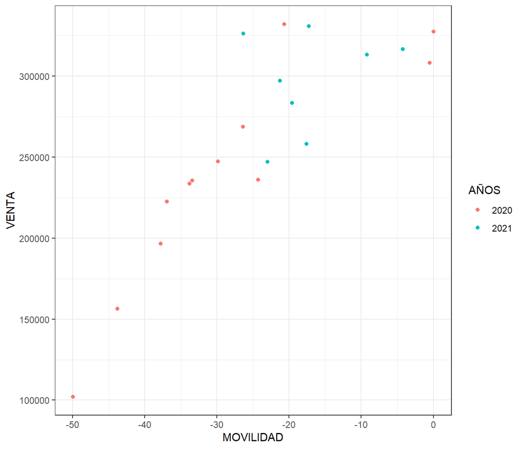

Gráfico Ventas vs. Movilidad Google

La gráfica podría responder a una ajuste lineal o poseer alguna componente asintótica (al final de la gráfica).

#### 1.3.2.1 Modelo 1

Estimación lineal VENTA ~ MOVILIDAD.

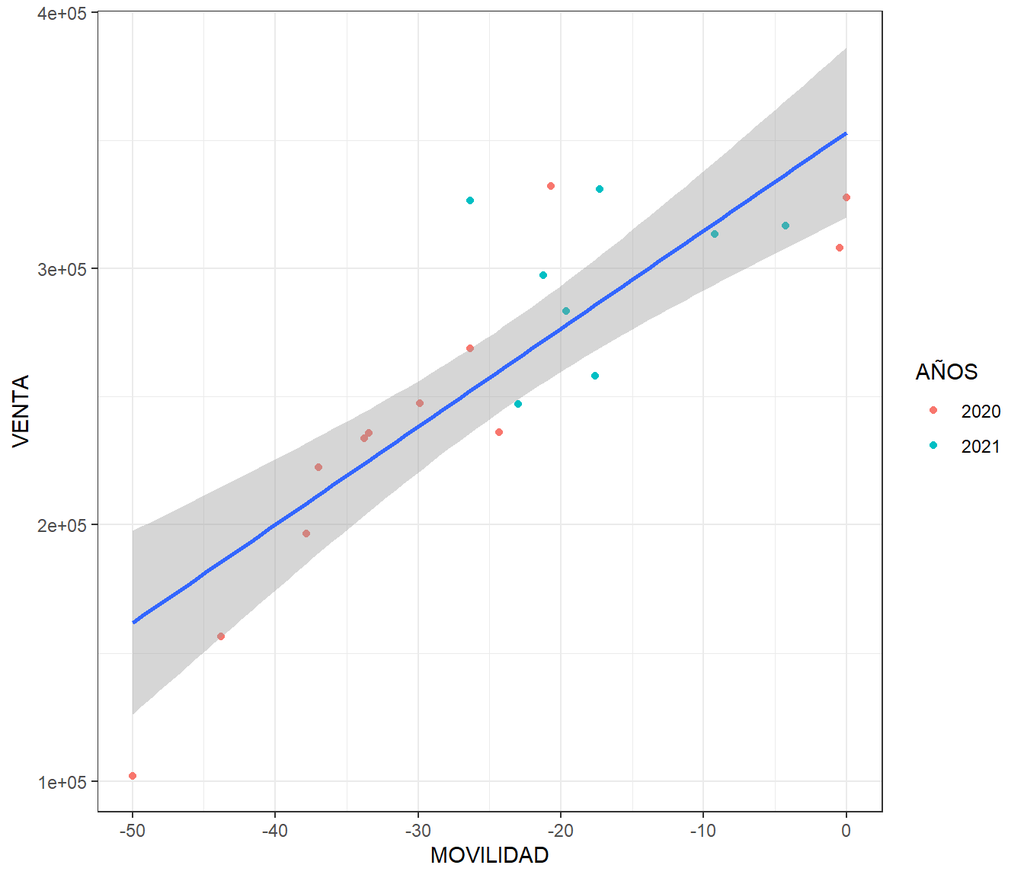

Características del Modelo 1

| r.squared | adj.r.squared | sigma | statistic | p.value | df | logLik | AIC | BIC | deviance | df.residual | nobs |
| --- | --- | --- | --- | --- | --- | --- | --- | --- | --- | --- | --- |
| 0.7074113 | 0.6911564 | 34396.63 | 43.5198 | 3.4e-06 | 1 | -236.2394 | 478.4789 | 481.4661 | 21296301814 | 18 | 20 |

Vemos los parámetros del Modelo 1:

Parámetros del Modelo 1

| term | estimate | std.error | statistic | p.value |
| --- | --- | --- | --- | --- |
| (Intercept) | 353047.69 | 15800.2671 | 22.344413 | 0.0e+00 |
| MOVILIDAD | 3826.13 | 579.9843 | 6.596954 | 3.4e-06 |

Esto nos dice que la demanda se puede pronosticar con una fórmula del tipo:

$VENTA=353047.69+3826.13*MOVILIDAD$

Ampliando los datos:

Ventas reales y estimadas - residuos

| VENTA | MOVILIDAD | .fitted | .resid | .hat | .sigma | .cooksd | .std.resid |
| --- | --- | --- | --- | --- | --- | --- | --- |
| 327529.2 | 0.00 | 353047.7 | -25518.494 | 0.2110071 | 34701.21 | 0.0932823 | -0.8352234 |
| 308131.3 | -0.49 | 351172.9 | -43041.591 | 0.2044449 | 33402.75 | 0.2529010 | -1.4029343 |
| 236001.6 | -24.31 | 260034.5 | -24032.886 | 0.0500748 | 34884.92 | 0.0135454 | -0.7168782 |
| 102108.5 | -49.96 | 161894.3 | -59785.763 | 0.2446148 | 31215.09 | 0.6475594 | -1.9998512 |
| 156361.7 | -43.81 | 185425.0 | -29063.260 | 0.1638741 | 34544.16 | 0.0836747 | -0.9240440 |
| 196567.2 | -37.82 | 208343.5 | -11776.276 | 0.1059091 | 35264.71 | 0.0077647 | -0.3620773 |
| 222461.0 | -36.94 | 211710.5 | 10750.530 | 0.0991122 | 35287.07 | 0.0059646 | 0.3292901 |
| 233631.3 | -33.79 | 223762.8 | 9868.522 | 0.0783918 | 35305.92 | 0.0037986 | 0.2988568 |
| 235666.4 | -33.43 | 225140.2 | 10526.216 | 0.0763830 | 35294.01 | 0.0041927 | 0.3184274 |
| 247434.9 | -29.85 | 238837.7 | 8597.172 | 0.0604170 | 35328.41 | 0.0021377 | 0.2578530 |
| 268824.5 | -26.37 | 252152.7 | 16671.841 | 0.0518823 | 35149.38 | 0.0067795 | 0.4977790 |
| 332086.5 | -20.69 | 273885.1 | 58201.426 | 0.0527446 | 32285.75 | 0.0841491 | 1.7385382 |
| 326327.1 | -26.33 | 252305.7 | 74021.396 | 0.0518242 | 30212.64 | 0.1334774 | 2.2100240 |
| 297235.6 | -21.24 | 271780.7 | 25454.897 | 0.0518589 | 34821.32 | 0.0157964 | 0.7600095 |
| 330872.9 | -17.28 | 286932.2 | 43940.724 | 0.0620753 | 33639.72 | 0.0575778 | 1.3190685 |
| 283338.5 | -19.61 | 278017.3 | 5321.206 | 0.0549843 | 35368.93 | 0.0007367 | 0.1591383 |
| 247142.5 | -22.97 | 265161.5 | -18018.999 | 0.0501945 | 35108.62 | 0.0076346 | -0.5375235 |
| 258117.4 | -17.61 | 285669.6 | -27552.153 | 0.0608833 | 34715.62 | 0.0221467 | -0.8265705 |
| 313391.1 | -9.20 | 317847.3 | -4456.203 | 0.1105798 | 35375.28 | 0.0011731 | -0.1373712 |
| 316716.6 | -4.24 | 336824.9 | -20108.305 | 0.1587440 | 34992.15 | 0.0383292 | -0.6373757 |

Graficamos el modelo 1 ampliado:

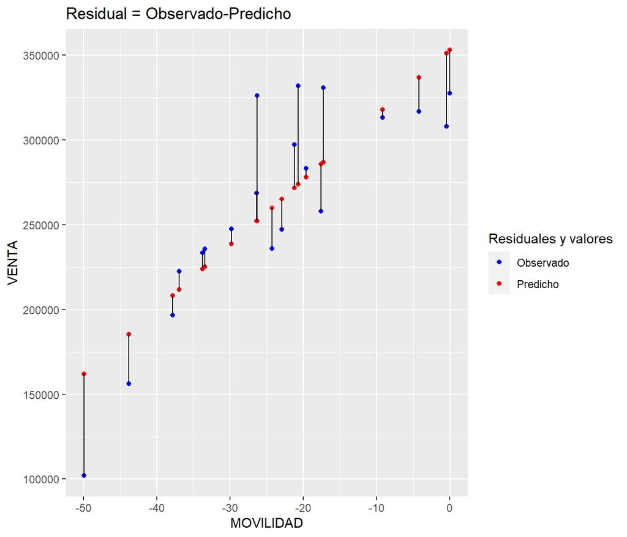

*Visualizando los supuestos del modelo:*

*a) Q-QPlot*

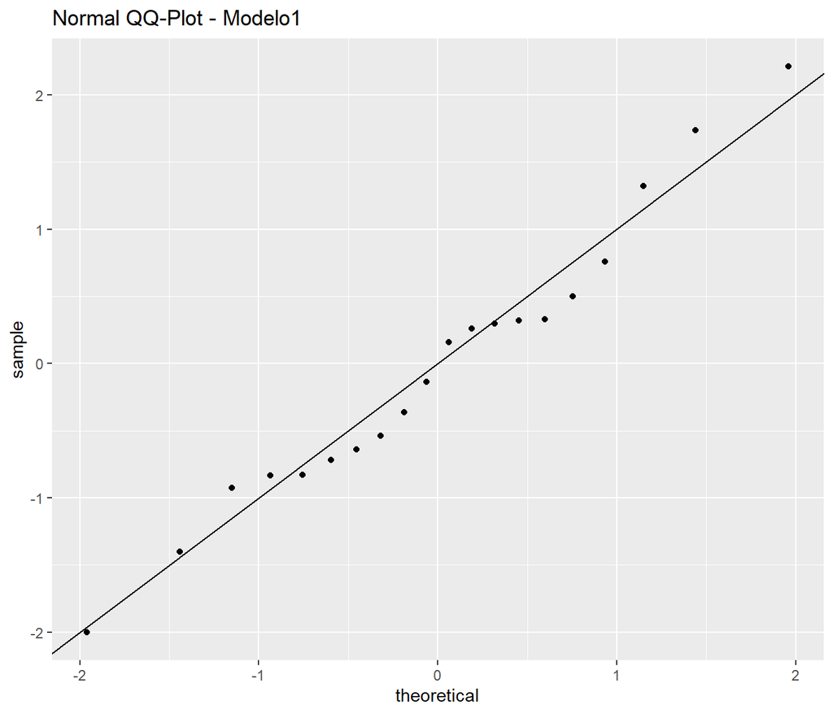

Observamos un resultado favorable ya que la nube de puntos se mantiene cercana a la recta.

*b) Valores Predichos - Residuos*

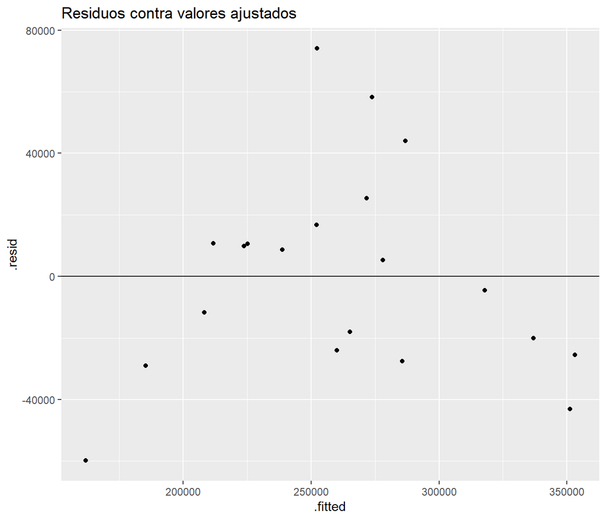

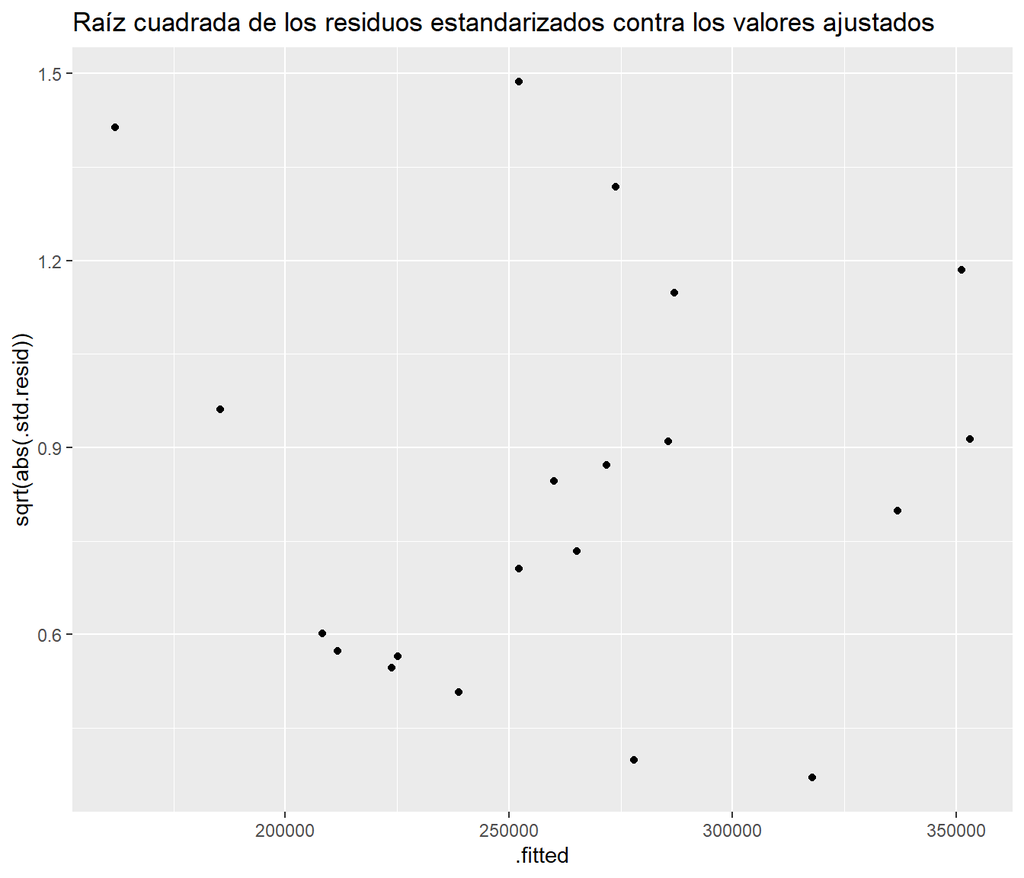

Se sostienen los supuestos anteriores.

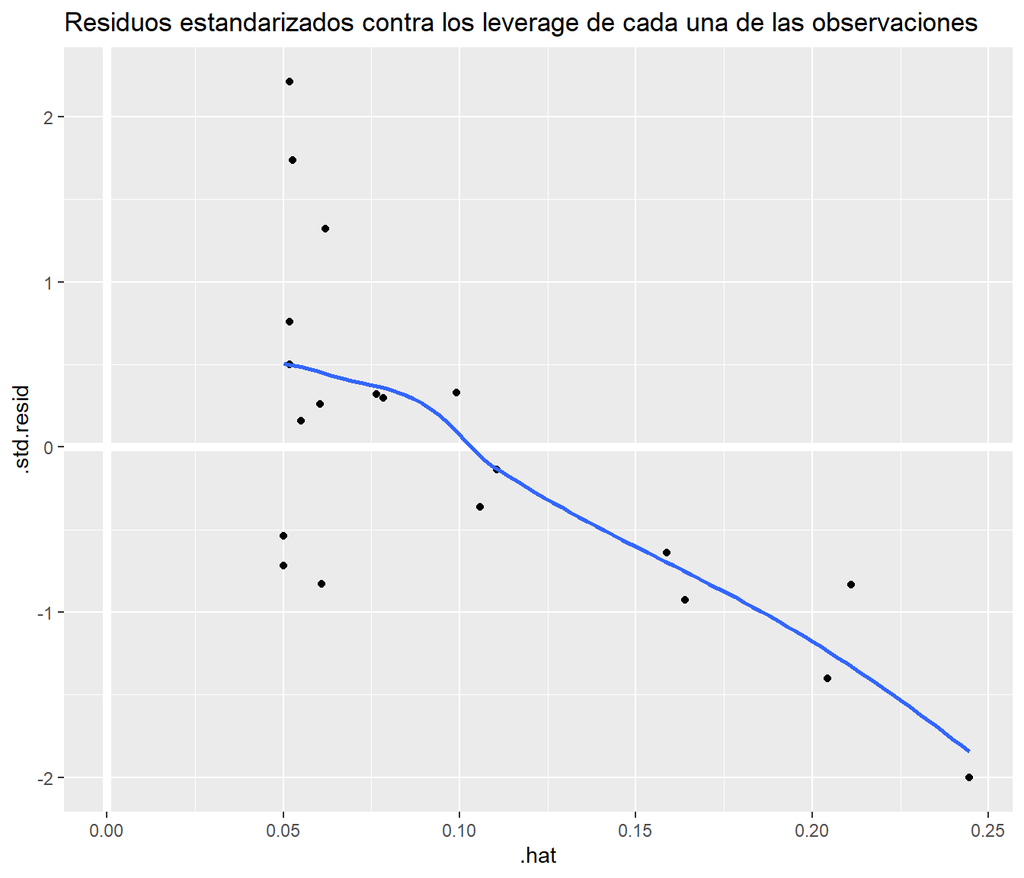

No parecen existir valores influyentes que “arrastren” al resto.

Prueba general:

```
##
## Call:
## lm(formula = VENTA ~ MOVILIDAD, data = baseconjuntaest)
##
## Coefficients:
## (Intercept)    MOVILIDAD
##      353048         3826
##
##
## ASSESSMENT OF THE LINEAR MODEL ASSUMPTIONS
## USING THE GLOBAL TEST ON 4 DEGREES-OF-FREEDOM:
## Level of Significance =  0.05
##
## Call:
##  gvlma(x = modelo1)
##
##                       Value  p-value                   Decision
## Global Stat        10.25921 0.036280 Assumptions NOT satisfied!
## Skewness            0.74146 0.389192    Assumptions acceptable.
## Kurtosis            0.02247 0.880839    Assumptions acceptable.
## Link Function       9.36944 0.002206 Assumptions NOT satisfied!
## Heteroscedasticity  0.12583 0.722792    Assumptions acceptable.
```

**Interpretación de la función gvlma:**

- Global Stat: Rechazo de la hipótesis nula significa que no se cumple el supuesto de linealidad entre las variables.
- Skewness: Aceptación de la hipótesis nula significa que se puede suponer normalidad (no se observaron asimetrías significativas).
- Kurtosis: Aceptación de la hipótesis nula significa que se cumple el supuesto de normalidad debido a una curtosis poco significativa (cercana a cero = pocos valores atípicos).
- Link Function: Rechazo de la hipótesis nula significa que el modelo de regresión lineal no es el más adecuado para el fenómeno estudiado.
- Heteroscedasticy: En la última linea se refiere a la hipótesis alternativa a “H0: residuos homocedásticos”; la salida de R indica que podemos asumir H0.

*Resumiendo:* El modelo sirve regularmente, porque podría hallarse un modelo no lineal que ajuste con mayor precisión.

#### 1.3.2.2 Predicciones para otros valores

Ejemplos de predicciones de Venta para otras movilidades

| MOVILIDAD | VENTApredicha |
| --- | --- |
| -10 | 314786.4 |
| 5 | 372178.3 |
| 0 | 353047.7 |
| 12 | 398961.2 |
| -4 | 337743.2 |
| 6 | 376004.5 |

#### 1.3.2.3 Modelo 2

Aproximación lineal considerando además de la movilidad la venta observada en el mes anterior: VENTA ~ MOVILIDAD + VENTAant

Características del Modelo 2

| r.squared | adj.r.squared | sigma | statistic | p.value | df | logLik | AIC | BIC | deviance | df.residual | nobs |
| --- | --- | --- | --- | --- | --- | --- | --- | --- | --- | --- | --- |
| 0.7325217 | 0.7010536 | 33841 | 23.27828 | 1.36e-05 | 2 | -235.3421 | 478.6843 | 482.6672 | 19468622178 | 17 | 20 |

Mejoró un poco el $r^2$.

Vemos los parámetros del Modelo 2:

Parámetros del Modelo 2

| term | estimate | std.error | statistic | p.value |
| --- | --- | --- | --- | --- |
| (Intercept) | 2.764463e+05 | 62596.806334 | 4.416300 | 0.0003777 |
| MOVILIDAD | 3.087769e+03 | 816.826710 | 3.780201 | 0.0014937 |
| VENTAant | 2.248461e-01 | 0.177983 | 1.263301 | 0.2235325 |

Esto nos dice que la demanda se puede pronosticar con una fórmula del tipo:

$VENTA=276446.3+3087.77*MOVILIDAD+0.224846*VENTAant$

#### 1.3.2.4 Comparamos Varios modelos a la vez

Consideramos diferentes combinaciones entre las variables y generamos diferentes modelos cuyo ajuste rankeamos por los valores de AIC.

Ranking de Modelos

| r.squared | AIC | Modelo | DeltaAIC |
| --- | --- | --- | --- |
| 0.8768879 | 463.1654 | Fit8 | 0.00000 |
| 0.8171758 | 475.0740 | Fit7 | 11.90859 |
| 0.8193978 | 476.8295 | Fit9 | 13.66403 |
| 0.7745061 | 477.2694 | Fit3 | 14.10395 |
| 0.7745061 | 477.2694 | Fit6 | 14.10395 |
| 0.7074113 | 478.4789 | Fit1 | 15.31345 |
| 0.7336340 | 478.6010 | Fit4 | 15.43552 |
| 0.7325217 | 478.6843 | Fit2 | 15.51886 |
| 0.5548962 | 490.8697 | Fit5 | 27.70424 |

Luego del planteo de varios modelos el que predice con menor error es el modelo 8 representado por la aproximación:

VENTA ~ MOVILIDADdif + VENTAant

De acuerdo a la expresión:

$VENTA=41593.5+0.84293*VENTAant+4228.18*MOVILIDADdif$

El mismo resultado se podría haber obtenido recorriendo todos los modelos lineales posibles, generados por R mediante diversos métodos. Como ejemplo de estas metodologías utilizamos la función “step”.

```
## Start:  AIC=409.51
## VENTA ~ MOVILIDAD + AÑO + MES + DIA + VENTAant + MOVILIDADdif
##
##                Df  Sum of Sq        RSS    AIC
## - MES           1   62972606 7.8139e+09 407.67
## - DIA           1  111986712 7.8629e+09 407.79
## - AÑO           1  215897068 7.9668e+09 408.06
## - MOVILIDAD     1  445273643 8.1962e+09 408.62
## <none>                       7.7510e+09 409.51
## - MOVILIDADdif  1 8040347560 1.5791e+10 421.74
## - VENTAant      1 9177502544 1.6928e+10 423.13
##
## Step:  AIC=407.67
## VENTA ~ MOVILIDAD + AÑO + DIA + VENTAant + MOVILIDADdif
##
##                Df  Sum of Sq        RSS    AIC
## - DIA           1 1.8183e+08 7.9958e+09 406.13
## - AÑO           1 3.3355e+08 8.1475e+09 406.50
## - MOVILIDAD     1 3.9457e+08 8.2085e+09 406.65
## <none>                       7.8139e+09 407.67
## + MES           1 6.2973e+07 7.7510e+09 409.51
## - VENTAant      1 9.2751e+09 1.7089e+10 421.32
## - MOVILIDADdif  1 1.0749e+10 1.8563e+10 422.97
##
## Step:  AIC=406.13
## VENTA ~ MOVILIDAD + AÑO + VENTAant + MOVILIDADdif
##
##                Df  Sum of Sq        RSS    AIC
## - AÑO           1 3.4724e+08 8.3430e+09 404.98
## - MOVILIDAD     1 3.9654e+08 8.3923e+09 405.10
## <none>                       7.9958e+09 406.13
## + DIA           1 1.8183e+08 7.8139e+09 407.67
## + MES           1 1.3282e+08 7.8629e+09 407.79
## - VENTAant      1 9.4004e+09 1.7396e+10 419.68
## - MOVILIDADdif  1 1.0729e+10 1.8725e+10 421.15
##
## Step:  AIC=404.98
## VENTA ~ MOVILIDAD + VENTAant + MOVILIDADdif
##
##                Df  Sum of Sq        RSS    AIC
## - MOVILIDAD     1 6.1781e+08 8.9608e+09 404.41
## <none>                       8.3430e+09 404.98
## + AÑO           1 3.4724e+08 7.9958e+09 406.13
## + MES           1 2.8453e+08 8.0585e+09 406.29
## + DIA           1 1.9552e+08 8.1475e+09 406.50
## - VENTAant      1 1.0204e+10 1.8547e+10 418.96
## - MOVILIDADdif  1 1.1126e+10 1.9469e+10 419.93
##
## Step:  AIC=404.41
## VENTA ~ VENTAant + MOVILIDADdif
##
##                Df  Sum of Sq        RSS    AIC
## <none>                       8.9608e+09 404.41
## + MOVILIDAD     1 6.1781e+08 8.3430e+09 404.98
## + AÑO           1 5.6852e+08 8.3923e+09 405.10
## + DIA           1 2.0261e+08 8.7582e+09 405.95
## + MES           1 1.8454e+08 8.7763e+09 405.99
## - MOVILIDADdif  1 2.6873e+10 3.5834e+10 430.13
## - VENTAant      1 5.0059e+10 5.9019e+10 440.11
```

```
##
## Call:
## lm(formula = VENTA ~ VENTAant + MOVILIDADdif, data = baseconjuntaest)
##
## Coefficients:
##  (Intercept)      VENTAant  MOVILIDADdif
##    4.159e+04     8.429e-01     4.228e+03
```

Con esta función también se concluye como modelo:

VENTA ~ MOVILIDADdif + VENTAant

**Este recorrido es parte del entrenamiento y aprendizaje - becas EVC-CIN**

[output not shown]